# Data Analysis for Business, Economics and Policy

# 7 CHAPTER 06: Testing Hypotheses

A hypothesis is a statement about a population, or general pattern. Testing a hypothesis amounts to gathering information from a dataset and, based on that information, deciding whether that hypothesis is false or true in the population, or general pattern. Thus, **hypothesis testing** means analyzing the data at hand to make a decision about the hypothesis. Two decisions are possible: rejecting the hypothesis or not rejecting it. We reject the hypothesis if there is enough evidence against it. We don’t reject it if there isn’t enough evidence against it. We may have insufficient evidence against a hypothesis either if the hypothesis is true or if it is not true but the evidence is weak.

Testing a hypothesis is a way of making an inference, with a focus on a specific statement. As with any kind of inference, we have to assess external validity. The first step is defining the statistic that would answer our question. Often that statistic is an *average*, or the *difference between two average* values.

```r
# CASE STUDY: Comparing Online and Offline Prices: Testing the Difference
pd <- read.csv("input/online_offline_ALL_clean.csv")

# filter the data
pd <- pd |>
  filter(COUNTRY == "USA") |>
  filter(PRICETYPE == "Regular Price") |>
  filter(is.na(sale_online)) |>
  filter(!is.na(price)) |>
  filter(!is.na(price_online))

# drop errors (+1000 dollars)
pd <- pd |> filter(price < 1000)

# creating diff variable
pd <- pd |> mutate(diff = price_online - price)

# Check the main descriptives
modelsummary::datasummary(diff ~ Mean + SD + Min + Max + Median + Max, data = pd)
```

|  | Mean | SD | Min | Max | Median | Max |
| --- | --- | --- | --- | --- | --- | --- |
| diff | 0.05 | 9.99 | −380.13 | 415.27 | 0.00 | 415.27 |

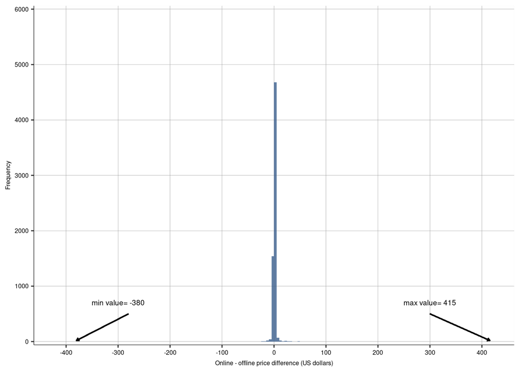

```r
# plotting online-offline price differences
p1 <- ggplot(data = pd, aes(diff)) +
  geom_histogram(
    binwidth = 5, boundary = 0, closed = "left",
    fill = color[1], size = 0.25, alpha = 0.8, show.legend = F, na.rm = TRUE
  ) +
  labs(x = "Online - offline price difference (US dollars)", y = "Frequency") +
  theme_bg() +
  scale_x_continuous(limits = c(-420, 420), breaks = seq(-400, 420, by = 100)) +
  scale_y_continuous(limits = c(0, 6000), breaks = seq(0, 6000, by = 1000), expand = c(0.01, 0.01)) +
  geom_segment(aes(x = 300, y = 500, xend = 415, yend = 20), arrow = arrow(length = unit(0.1, "cm"))) +
  annotate("text", x = 300, y = 700, label = "max value= 415", size = 2.5) +
  geom_segment(aes(x = -280, y = 500, xend = -380, yend = 20), arrow = arrow(length = unit(0.1, "cm"))) +
  annotate("text", x = -300, y = 700, label = "min value= -380", size = 2.5)
p1
```

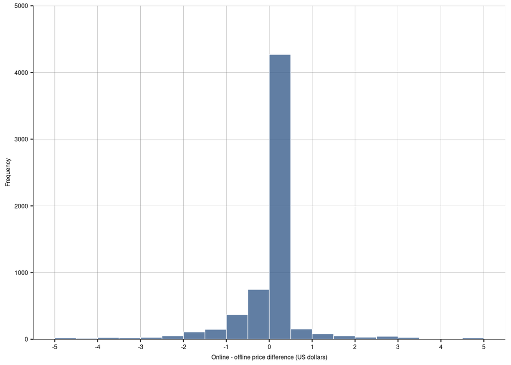

```r
# 4.99999 not 5 -- needed because of data imported from stata may be stored wierdly.
# pd1 <- subset(pd, abs(pd$diff) < 4.999999)
# Hmisc::describe(pd1$diff)

# plotting online-offline price differences (+-5 dollar price difference)
p2 <- ggplot(data = pd, aes(diff)) +
  geom_histogram(
    binwidth = 0.5, boundary = -0, closed = "left",
    color = color.outline, fill = color[1], size = 0.25, alpha = 0.8, show.legend = F, na.rm = TRUE
  ) +
  labs(x = "Online - offline price difference (US dollars)", y = "Frequency") +
  theme_bg() +
  expand_limits(x = 0.01, y = 0.01) +
  scale_x_continuous(limits = c(-5, 5), breaks = seq(-5, 5, by = 1)) +
  scale_y_continuous(expand = c(0.00, 0.00), limits = c(0, 5000), breaks = seq(0, 5000, by = 1000))
p2
```

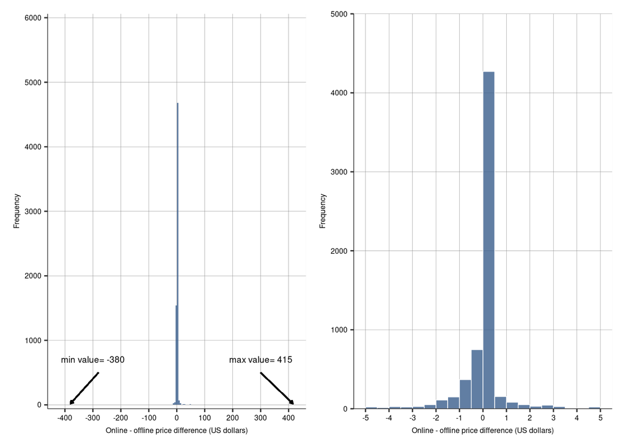

```r
p1 | p2
```

## Null Hypothesis, Alternative Hypothesis

After specifying the statistic that helps answer our question, we need to state two competing hypotheses, of which only one can be true. The first one is the **null hypothesis** ($H_0$), the second one is the **alternative hypothesis** ($H_1$). These hypotheses are formulated in terms of the unknown **true value** of the statistics. Together, the null and the alternative should cover all possibilities we are interested in.
$$H_0: s_{true} = 0 \\ H_1: s_{true} \not = 0$$

The case when we test if $H_1 : s_{true} \not = 0$ is called **two-sided alternative** as it allows for $s_{true}$ to be either greater than zero or less than zero. The other case is working with a **one-sided alternative**, when we are indeed interested if a statistic is positive.
$$H_0 : s_{true} \le 0 \\ H_1 : s_{true} \gt 0$$

## 7.1 The t-Test

Following the logic of hypothesis testing, when we look at the evidence to see if we want to reject the null or maintain our assumption that it’s true, the evidence we look for is how far the estimated value of the statistic is from zero, its hypothesized value. We reject the null if the estimate is large, and we do not reject it if the estimate is not very far. How far is far enough for rejecting requires a measure of the distance -> the **t-statistic**. More generally, the t-statistic is a **test statistic**. **A test statistic is a measure of the distance of the estimated value of the statistic from what its true value would be if $H_0$ were true**.

Consider $H_0: s_{true} = 0$ , $H_1: s_{true} \not = 0$, where $s$ is an average, or the difference of that average from a number, or a difference of two averages. The null and alternative are about the true value of the statistic: $s_{true}$. Our data contains information to compute the estimated value of the statistic: $\hat{s}$. The t-statistic for this hypotheses uses the estimated value $\hat{s}$ and its standard error:
$$t = \frac{\hat{s}}{SE(\hat{s})}$$
When $\hat{s}$ is the average of a variable *x*, the t-statistic is simply
$$t = \frac{\bar{x}}{SE(\bar{x})}$$
When $\hat{s}$ is the average of a variable *x* minus a number, the t-statistic is
$$t = \frac{\hat{x} - number}{SE(\hat{x})}$$
When $\hat{s}$ is the difference between two averages, say, $\bar{x}_A$ and $\bar{x}_B$, the t-statistic is
$$t = \frac{\bar{x}_A - \bar{x}_B}{SE(\bar{x}_A - \bar{x}_B)}$$

The sign of the t-statistic is the same as the sign of $\hat{s}$. If $\hat{s}$ is positive, the t-statistic is positive; if $\hat{s}$ is negative, the t-statistic is negative. The magnitude of the t-statistic measures the distance of $\hat{s}$ from what $s_{true}$ would be if the null were true. The unit of distance is the standard error.

## 7.2 Making a Decision; False Negatives, False Positives

In hypothesis testing the decision of rejecting the null or not rejecting it is based on a clear rule specified in advance. To be specific, the decision rule in statistical testing is comparing the test statistic to a **critical value**. The critical value thus tell us whether the test statistic is large enough to reject the null. To be transparent, we need to set the critical value before looking at the test statistic, but the practice is to use a commonly accepted critical value. The critical value reflects a preference for how conservative we want to be with the evidence.

We can make one of two decisions with hypothesis testing: we reject the null or we don’t reject the null. That decision may be right or wrong. We say that our decision is a **false positive** (Type-I error) if we reject the null when it is true, and a **false negative** (Type-II error) if we do not reject the null even though it’s not true. False positives and false negatives are both wrong, but they are not equally wrong. The way we set up the null and the alternative, wrongly rejecting the null is a bigger mistake than wrongly accepting it. Therefore, the critical value is to be chosen in a way that makes false positives rare.

Talking about a t-test for a null with a two-side alternative, a commonly applied critical value for a t-statistic is $\pm2$: reject the null if the t-statistic is smaller than -2 or larger than +2; don’t reject the null if the t-statistic is between -2 and +2. That way the probability of a false positive is 5%. Based on the same argument, we can set other critical values that correspond to different probabilities of a false positive. If we make the critical values -2.6 and +2.6, the chance of a false positive is 1%. With critical values -1.6 and +1.6 it is 10%. Data analysts avoid biases using the same $\pm2$ critical value of the t-test regardless of the data and hypothesis they are testing.

The chance of a false negative depends on two things: how far the true value is from the value defined in the null hypothesis, and how large the sample is. The probability of a false positive is called the **size of the test**. The maximum probability that we tolerate is the **level of significance**. When we fix the level of significance at 5% and end up rejecting the null, we say that the statistic we tested is significant at 5%. The probability of avoiding a false negative is the **power of the test**. Thus, we usually fix the level of significance at 5% and hope for a high power, which is more likely the larger the sample and the further away the true value is from what’s in the null. Tests with more observations are more power in general.

## 7.3 The p-Value

The **p-value** informs us about the probability of a *false positive*. To be more precise, the p-value is the probability that the test statistic will be as large as, or larger than, what we calculate from the data, *if the null hypothesis is true*. Thus, the p-value is the smallest significance level at which we can reject $H_0$ given the value of the test statistic in the data. Because the p-value tells us the smallest level of significance at which we can reject the null, it summarizes all the information we need to make the decision.

```r
# CASE STUDY: Comparing Online and Offline Prices: Testing the Difference
t.test(pd$diff, mu = 0)
```

```
##
##  One Sample t-test
##
## data:  pd$diff
## t = 0.4, df = 6438, p-value = 0.7
## alternative hypothesis: true mean is not equal to 0
## 95 percent confidence interval:
##  -0.19  0.30
## sample estimates:
## mean of x
##     0.054
```

Conclusion: The t-statistic (0.4) is well within $\pm2$, thus we can’t reject the hypothesis that the average price difference is zero in the population of products represented by the data. Doing so would be inconsistent with our goal to keep the probability of false positive below 5%.

We arrive at the same conclusion with the help of the p-value (0.7). That means that there is a 66% chance that we could observe a price difference of this magnitude (or a larger one) if the null is true. It also means that the smallest level of significance at which we could reject the null is 66%, well over the 5% level of significance we have chosen.

## 7.4 Steps of Hypothesis Testing

1. Define the **statistic** that corresponds to your question.
2. Initial assessment of **external validity**: general pattern of interest, general pattern represented by the data.
3. State the **null** and **alternative** hypotheses.
4. Choose a **critical value**. In practice, that should correspond to 5%.
5. Calculate the **test statistic** from the data.
6. Make a decision based on the calculated test statistic and the critical value.
7. Alternative to steps 4-6, calculate the **p-value** and make a decision by comparing it to a pre-set level of significance that in practice will usually be 5%.
8. Interpret the results.
9. Final assessment of external validity. Would the same decision be fine for the population, or general pattern, of interest

## 7.5 One-Sided Alternatives

Testing a null hypothesis against a one-sided alternative means having an inequality in the null hypothesis instead of an equality: $H_0:s_{true} \le 0$ against $H_1:s_{true} \gt 0$ and $H_0:s_{true} \ge 0$ against $H_1:s_{true} \lt 0$. Having only one of the inequalities leads to focusing on one side of the test statistic only. Focusing on deviations in one direction means that we care about one half of the sampling distribution of the test statistic.

The probability of a false positive is smaller in this case. We don’t reject the null if the test statistic falls in the region that is specified in the null hypothesis. Thus, we make a false positive decision only half of the time. The probability of a false positive decision here is therefore half of the probability of a false positive in the corresponding two-sided test.

Therefore, the practical way to test a one-sided hypothesis is a two-step procedure.

1. If the test statistic is in the region of the null, don’t reject the null. This happens if $\hat s$ is in the region of null ($H_0:s_{true} \le 0$ against $H_1:s_{true} \gt 0$).
2. If the test statistic is in the region of the alternative, calculate the p-value of the null hypothesis of the equality and divide the p-value by two.

## 7.6 Testing Multiple Hypotheses

The simplest decision rule to testing a hypothesis consists of calculating a p-value from the data and comparing it to a pre-set level of significance. So far, we have considered cases with one pair of hypotheses: a null and an alternative. Often, though, data analysis involves testing multiple null hypotheses, each with and an alternative. Testing multiple hypotheses is an issue because the statistical theory of testing, and the corresponding tools, have been developed for testing a single null hypothesis. In multiple hypothesis testing, the question is the likelihood that any one of the true nulls will be wrongfully rejected.

```r
# CASE STUDY: Comparing Online and Offline Prices: Testing the Difference
# calculating multiple hypotheses for each retailer in the data (16)
spd <- split(pd, pd$retailer, drop = FALSE)
out <- vector("list", length = length(spd))
out <- lapply(1:length(spd), function(x) out[[x]] <- t.test(spd[[x]]$diff, mu = 0))
out
```

```
## [[1]]
##
##  One Sample t-test
##
## data:  spd[[x]]$diff
## t = 2, df = 119, p-value = 0.04
## alternative hypothesis: true mean is not equal to 0
## 95 percent confidence interval:
##  0.21 7.27
## sample estimates:
## mean of x
##       3.7
##
##
## [[2]]
##
##  One Sample t-test
##
## data:  spd[[x]]$diff
## t = -1, df = 545, p-value = 0.2
## alternative hypothesis: true mean is not equal to 0
## 95 percent confidence interval:
##  -3.16  0.73
## sample estimates:
## mean of x
##      -1.2
##
##
## [[3]]
##
##  One Sample t-test
##
## data:  spd[[x]]$diff
## t = -12, df = 1398, p-value <0.0000000000000002
## alternative hypothesis: true mean is not equal to 0
## 95 percent confidence interval:
##  -0.50 -0.36
## sample estimates:
## mean of x
##     -0.43
```

[output cut: 167 more lines]

```
##     -0.14
##
##
## [[16]]
##
##  One Sample t-test
##
## data:  spd[[x]]$diff
## t = 2, df = 75, p-value = 0.1
## alternative hypothesis: true mean is not equal to 0
## 95 percent confidence interval:
##  -0.38  3.10
## sample estimates:
## mean of x
##       1.4
```

```r
# creating a table with the 16 p-values if we carry out each test one by one
table_out <- pd |>
  group_by(retailer) |>
  group_modify(~ tidy(t.test(.x$diff)))
table_out <- table_out |>
  dplyr::select(retailer, estimate, p.value)
table_out
```

```
## # A tibble: 16 × 3
## # Groups:   retailer [16]
##    retailer estimate  p.value
##       <int>    <dbl>    <dbl>
##  1       44   3.74   3.81e- 2
##  2       45  -1.22   2.20e- 1
##  3       46  -0.429  5.80e-30
##  4       47   0.0516 9.72e- 2
##  5       48   0.421  3.39e- 2
##  6       49   2.41   2.02e- 1
##  7       50   0.606  1.02e- 1
##  8       51   0.284  6.16e- 2
##  9       53  -0.970  7.31e- 3
## 10       54  -0.0275 8.00e- 1
## 11       56  -0.486  3.79e- 2
## 12       57   0.932  1.01e- 4
## 13       58  -0.169  6.83e-12
## 14       59  -0.528  2.60e- 3
## 15       60  -0.138  6.97e- 1
## 16       62   1.36   1.23e- 1
```

# 8 CHAPTER 07: Simple Regression

We focus in the most important pattern of association: **mean dependence**. Mean-dependence tells whether, and to what extent, the mean of *y* is different when the value of *x* is different. **Regression** is the most widely used method of comparison in data analysis. **Simple regression analysis** uncovers mean-dependence between two variables. It amounts to comparing average values of one variable, called the dependent variable *(y)* for observations that are different in the other variable, the explanatory variable *(x)*. Discovering patterns of association between variables if often a good starting point if we are interested in **causal analysis**: uncovering the effect of one variable on another variable; or, we may be interested in **predictive analysis**: what to expect of a variable for various values of another variable.

**Regression analysis** is a method that uncovers the average value of a variable *y* for different values of variable *x*. Regression is a model for the **conditional mean**. The model for the conditional mean gives a rule that takes *x* values and tells what the mean value of *y* is.
$$E[y|x] = f(x) * \\ y^E = f(x) \\ y = f(x) + e **$$

* The expected value of *y* conditional on *x* is given by the function *f*.

** The actual value of *y* is equal to its expected value plus a deviation from it.

Regression analysis find patterns in the data by comparing observations with different values of the *x* variable **(explanatory variable, right-hand-side variable or regressor)** to see whether and how the mean value of the *y* variable **(explained variable, left-hand-side variable or regressand)** differs across them. Thus, we need data with variation in *x*. Usually, the more variation in *x*, the better because it allows for more comparisons.

## 8.1 Non-parametric Regression

**Non-parametric regressions** describe the $y^E = f(x)$ pattern without imposing a specific **functional form** of *f*. They let the data dictate what that function looks like. In contrast, **parametric regressions** impose a functional form on *f*. Parametric examples include linear functions: $f(x) = a + bx$.

When *x* has few values and there are many observations in the data, the best and most intuitive non-parametric regression shows average *y* for each and every value of *x*. With many *x* values and few observations for some, or all, *x* values, there are two ways to do non-parametric regression analysis: **bins** and **smoothing**. The first and more straightforward way is based on grouped values of *x*: bins. Bins are disjoint categories (no overlap) that span the entire range of *x* (no gaps). It can be visualized through **bin scatters**. Bin scatters show the average value of *y* that corresponds to each bin created from the values of *x*, in an *x-y* coordinate system. An alternative visualization of the same non-parametric regression is the **step function**. A step function shows average *y* over the entire range of the bins.

The second method produces a “smooth” graph that is both continuous and has no kink at any point. Non-parametric regression of this kind shows conditional means, smoothed to get a better image. One of the various methods available is called **lowess**. **Lowess** (locally weighted scatterplot smoothing) is one of the most widely non-parametric regression methods that produces a smooth graph. A lowess may be thought of as a smooth curve fit around a bin scatter. Similarly to density plots, we have to set the bandwidth for smoothing, a choice that affects the results. Smooth non-parametric regression methods do not produce numbers that would summarize $y^E = f(x)$ pattern. Instead, they provide a value of $y^E$ for each of the particular *x* values that occur in the data, as well as for all *x* values in-between. We interpret these graphs in qualitative, not quantitative ways. If we want to visualize a regression, it is a good practice to plot it **together with the scatterplot**.

```r
# CASE STUDY: Finding a Good Deal among Hotels with Simple Regression
hotels <- read_csv("input/hotels-vienna.csv")

# Apply filters:  3-4 stars, Vienna actual, without extreme value
hotels <- hotels |>
  filter(accommodation_type == "Hotel") |>
  filter(city_actual == "Vienna") |>
  filter(stars >= 3 & stars <= 4) |>
  filter(!is.na(stars)) |>
  filter(price <= 600)

# summary statistics on price
descr_price <- hotels |>
  dplyr::select(price) |>
  dplyr::summarize(
    mean = mean(price),
    sd = sd(price),
    min = min(price),
    max = max(price),
    p50 = quantile(price, .50),
    p95 = quantile(price, .95),
    n = length(price)
  )
descr_price
```

```
## # A tibble: 1 × 7
##    mean    sd   min   max   p50   p95     n
##   <dbl> <dbl> <dbl> <dbl> <dbl> <dbl> <int>
## 1  110.  42.2    50   383   100  183.   207
```

```r
# summary statistics on distance
descr_dist <- hotels |>
  dplyr::select(distance) |>
  dplyr::summarize(mean=mean(distance),
                  sd=sd(distance),
                  min=min(distance),
                  max=max(distance),
                  p50=quantile(distance,.50),
                  p95=quantile(distance,.95),
                  n=length(distance))
descr_dist
```

```
## # A tibble: 1 × 7
##    mean    sd   min   max   p50   p95     n
##   <dbl> <dbl> <dbl> <dbl> <dbl> <dbl> <int>
## 1  1.53  1.16     0   6.6   1.3   3.9   207
```

```r
# REGRESSION 1: CLOSE VS FAR REGRESSION WITH BINARY DISTANCE
hotels <- hotels |> mutate(dist2 = as.numeric(distance >= 2))
dist2 <- hotels |>
  group_by(dist2) |>
  dplyr::summarize(Eprice_cat2 = mean(price))
hotels <- left_join(hotels, dist2)
hotels <- hotels |> mutate(dist2 = recode(dist2, `0` = "Close", `1` = "Far"))

hotels |>
  group_by(dist2) |>
  dplyr::summarize(
    mean_dist = mean(distance),
    sd_dist = sd(distance),
    min_dist = min(distance),
    max_dist = max(distance),
    mean_price = mean(price),
    sd_price = sd(price),
    min_price = min(price),
    max_price = max(price),
    N = n()
  )
```

```
## # A tibble: 2 × 10
##   dist2 mean_dist sd_dist min_dist max_dist mean_price sd_price min_price
##   <chr>     <dbl>   <dbl>    <dbl>    <dbl>      <dbl>    <dbl>     <dbl>
## 1 Close     0.995   0.539        0      1.9      116.      43.1        54
## 2 Far       3.21    0.974        2      6.6       89.7     32.1        50
## # … with 2 more variables: max_price <dbl>, N <int>
```

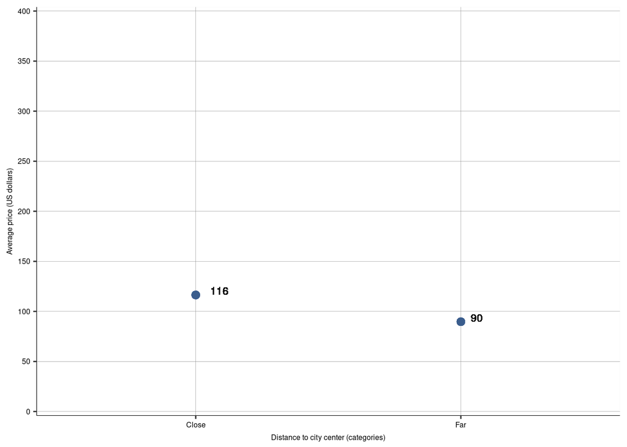

```r
# plotting the regression analysis (2 bins) with bin scatters
p1 <- ggplot(data = hotels) +
  geom_point(aes(x = dist2, y = Eprice_cat2),
    size = 2.5, color = color[1], fill = color[1], shape = 21, alpha = 0.4, na.rm = T
  ) +
  geom_text(aes(x = dist2, y = Eprice_cat2, label = round(Eprice_cat2)), hjust = -0.8, vjust = 0, color = "black", size = 3) +
  scale_y_continuous(expand = c(0.01, 0.01), limits = c(0, 400), breaks = seq(0, 400, by = 50)) +
  expand_limits(y = 0.01) +
  scale_x_discrete() +
  labs(x = "Distance to city center (categories)", y = "Average price (US dollars)") +
  theme_bg()
p1
```

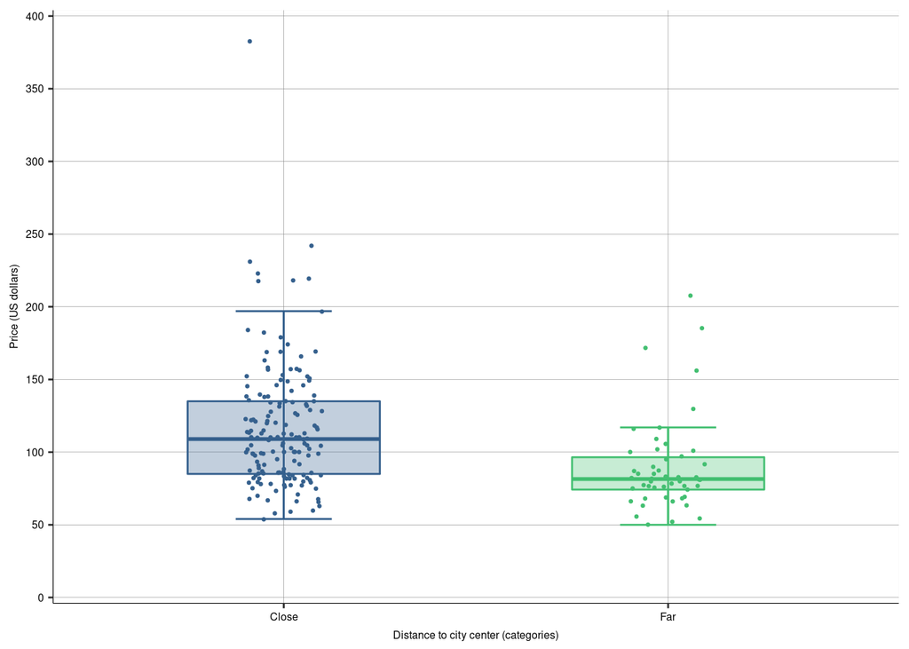

```r
# plotting the box plot
p2 <- ggplot(data = hotels, aes(x = dist2, y = price)) +
  stat_boxplot(aes(group = dist2), geom = "errorbar", width = 0.25, color = viridis(2, begin = 0.3, end = 0.7), size = 0.5, na.rm = T) +
  geom_boxplot(aes(group = dist2), color = viridis(2, begin = 0.3, end = 0.7), fill = viridis(2, begin = 0.3, end = 0.7), size = 0.5, width = 0.5, alpha = 0.3, na.rm = T, outlier.shape = NA) +
  geom_jitter(aes(color = dist2), position = position_jitter(0.1), size = 0.5, show.legend = F, na.rm = T) +
  labs(x = "Distance to city center (categories)", y = "Price (US dollars)") +
  scale_y_continuous(expand = c(0.01, 0.01), limits = c(0, 400), breaks = seq(0, 400, 50)) +
  expand_limits(y = 0.01) +
  scale_color_viridis(discrete = TRUE, option = "D", begin = 0.3, end = 0.7) +
  theme_bg()
p2
```

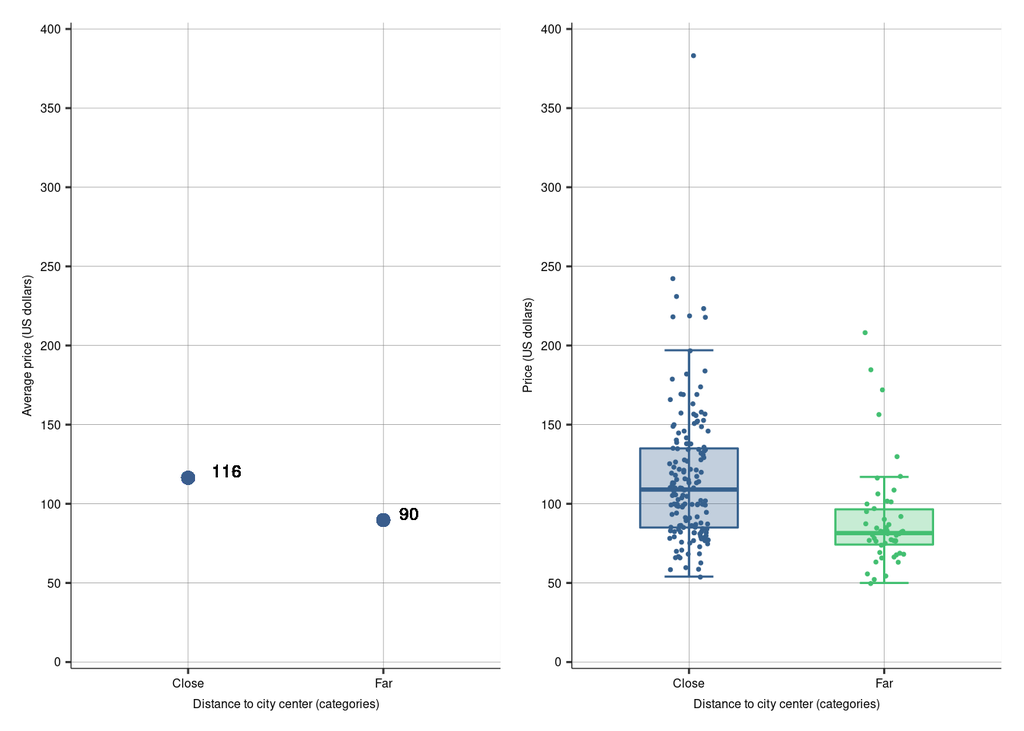

```r
p1 | p2
```

```r
### REGRESSION 2: 4 DISTANCE CATEGORIES
hotels <- hotels |> mutate(dist4 = 0.5 + 1 * as.numeric(hotels$distance >= 1) + 1 * as.numeric(hotels$distance >= 2) + 2.5 * as.numeric(hotels$distance >= 3))
dist4 <- hotels |>
  group_by(dist4) |>
  dplyr::summarize(Eprice_cat4 = mean(price))
hotels <- left_join(hotels, dist4)

hotels |>
  group_by(dist4) |>
  dplyr::summarize(
    mean_dist = mean(distance),
    sd_dist = sd(distance),
    min_dist = min(distance),
    max_dist = max(distance),
    mean_price = mean(price),
    sd_price = sd(price),
    min_price = min(price),
    max_price = max(price),
    N = n()
  )
```

```
## # A tibble: 4 × 10
##   dist4 mean_dist sd_dist min_dist max_dist mean_price sd_price min_price
##   <dbl>     <dbl>   <dbl>    <dbl>    <dbl>      <dbl>    <dbl>     <dbl>
## 1   0.5     0.554   0.283        0      0.9      133.      38.5        68
## 2   1.5     1.46    0.294        1      1.9       98.9     40.9        54
## 3   2.5     2.35    0.319        2      2.9       97.5     40.4        54
## 4   5       3.88    0.760        3      6.6       83.6     22.6        50
## # … with 2 more variables: max_price <dbl>, N <int>
```

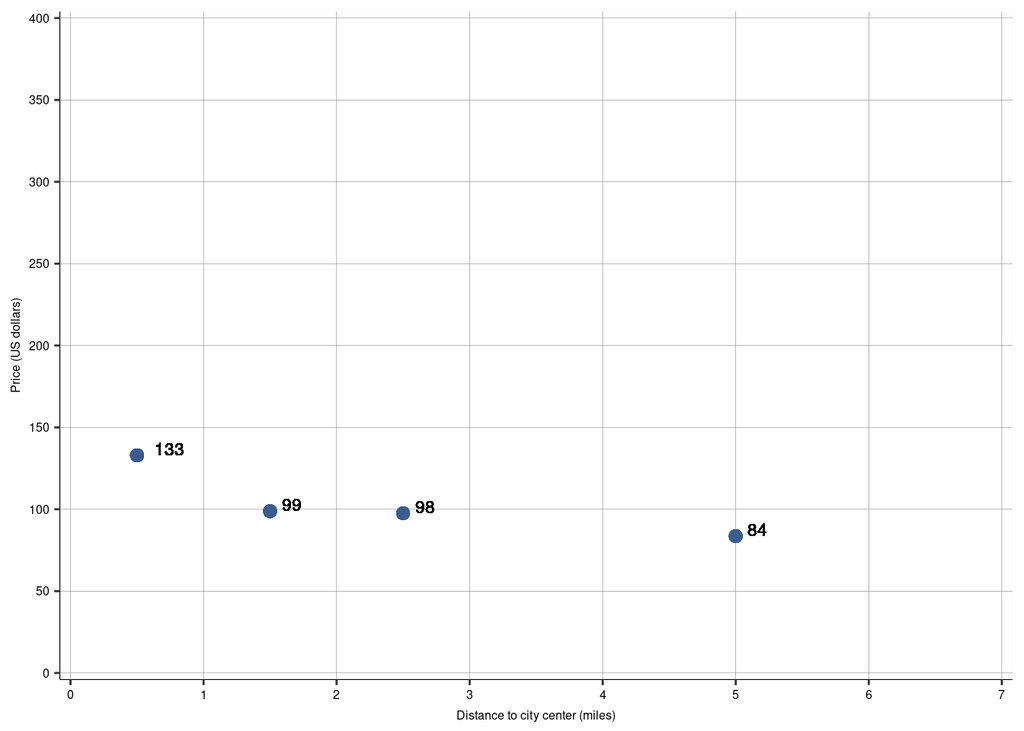

```r
# plotting the regression analysis (4 bins) with bin scatters
p3 <- ggplot(data = hotels) +
  geom_point(aes(x = dist4, y = Eprice_cat4),
    size = 2.5, color = color[1], fill = color[1], shape = 21, alpha = 0.4, na.rm = T
  ) +
  geom_text(aes(x = dist4, y = Eprice_cat4, label = round(Eprice_cat4)), hjust = -0.6, vjust = 0, color = "black", size = 3) +
  expand_limits(x = 0.01, y = 0.01) +
  coord_cartesian(xlim = c(0, 7), ylim = c(0, 400)) +
  scale_y_continuous(expand = c(0.01, 0.01), limits = c(0, 400), breaks = seq(0, 400, by = 50)) +
  scale_x_continuous(expand = c(0.01, 0.01), limits = c(0, 7), breaks = c(0, 1, 2, 3, 4, 5, 6, 7)) +
  labs(x = "Distance to city center (miles)", y = "Price (US dollars)") +
  theme_bg()
p3
```

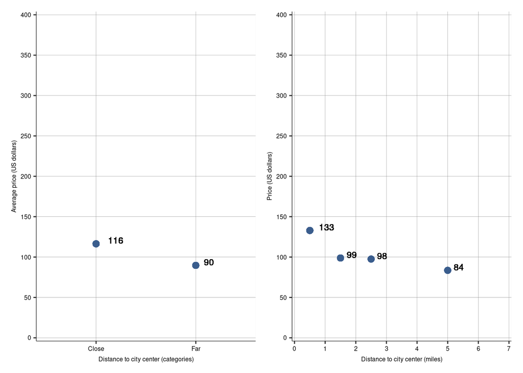

```r
p1 | p3
```

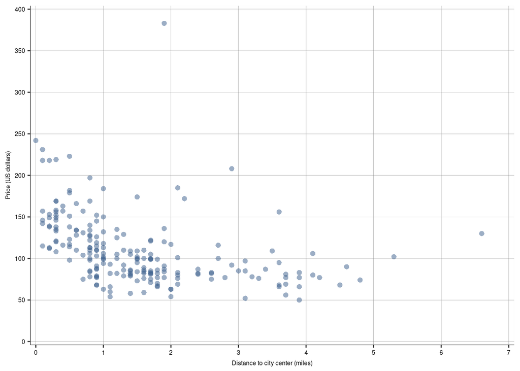

```r
# scatterplot of the whole data set (207 observations)
p4 <- ggplot(data = hotels) +
  geom_point(aes(x = distance, y = price), color = color[1], size = 2, shape = 16, alpha = 0.5, show.legend = F, na.rm = TRUE) +
  expand_limits(x = 0.01, y = 0.01) +
  scale_x_continuous(expand = c(0.01, 0.01), limits = c(0, 7), breaks = seq(0, 7, by = 1)) +
  scale_y_continuous(expand = c(0.01, 0.01), limits = c(0, 400), breaks = seq(0, 400, by = 50)) +
  labs(x = "Distance to city center (miles)", y = "Price (US dollars)") +
  theme_bg()
p4
```

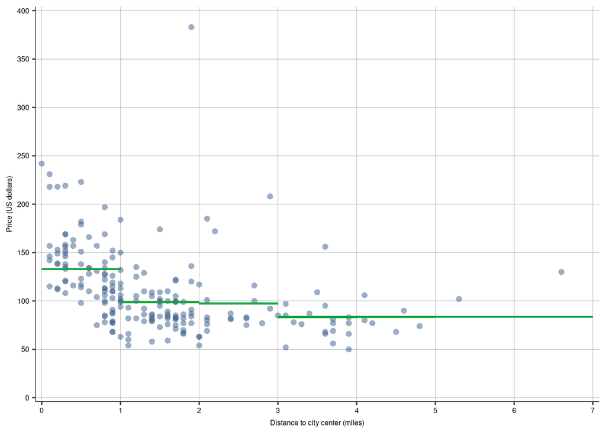

```r
# non-parametric regression with a step function (4 bins)
hotels <- hotels |> mutate(dist4_s = 1 * as.numeric(hotels$distance >= 1) + 1 * as.numeric(hotels$distance >= 2) + 1 * as.numeric(hotels$distance >= 3) + 1 * as.numeric(hotels$distance >= 4) + 1 * as.numeric(hotels$distance >= 5) + 1 * as.numeric(hotels$distance >= 6))
hotels$xend <- c(hotels$dist4_s + 1)
hotels$yend <- c(hotels$Eprice_cat4)

# plotting non-parametric regression including scatterplot (4 bins)
p5 <- p4 +
  geom_segment(data = hotels, aes(x = dist4_s, y = yend, xend = xend, yend = yend), color = color[2], size = 0.7, na.rm = TRUE)
p5
```

```r
### REGRESSION 3: 7 DISTANCE CATEGORIES
hotels <- hotels |> mutate(dist7_new = 0.5 + 1 * as.numeric(hotels$distance >= 1) + 1 * as.numeric(hotels$distance >= 2) + 1 * as.numeric(hotels$distance >= 3) + 1 * as.numeric(hotels$distance >= 4) + 1 * as.numeric(hotels$distance >= 5) + 1 * as.numeric(hotels$distance >= 6))
dist7_new <- hotels |>
  group_by(dist7_new) |>
  dplyr::summarize(Eprice_cat7_new = mean(price))
hotels <- left_join(hotels, dist7_new)
hotels |>
  group_by(dist7_new) |>
  dplyr::summarize(
    mean_dist = mean(distance),
    sd_dist = sd(distance),
    min_dist = min(distance),
    max_dist = max(distance),
    mean_dist = mean(price),
    sd_dist = sd(price),
    min_dist = min(price),
    max_dist = max(price),
    N = n()
  )
```

```
## # A tibble: 7 × 6
##   dist7_new mean_dist sd_dist min_dist max_dist     N
##       <dbl>     <dbl>   <dbl>    <dbl>    <dbl> <int>
## 1       0.5     133.     38.5       68      242    81
## 2       1.5      98.9    40.9       54      383    76
## 3       2.5      97.5    40.4       54      208    22
## 4       3.5      80.6    23.2       50      156    20
## 5       4.5      82.5    13.6       68      106     6
## 6       5.5     102      NA        102      102     1
## 7       6.5     130      NA        130      130     1
```

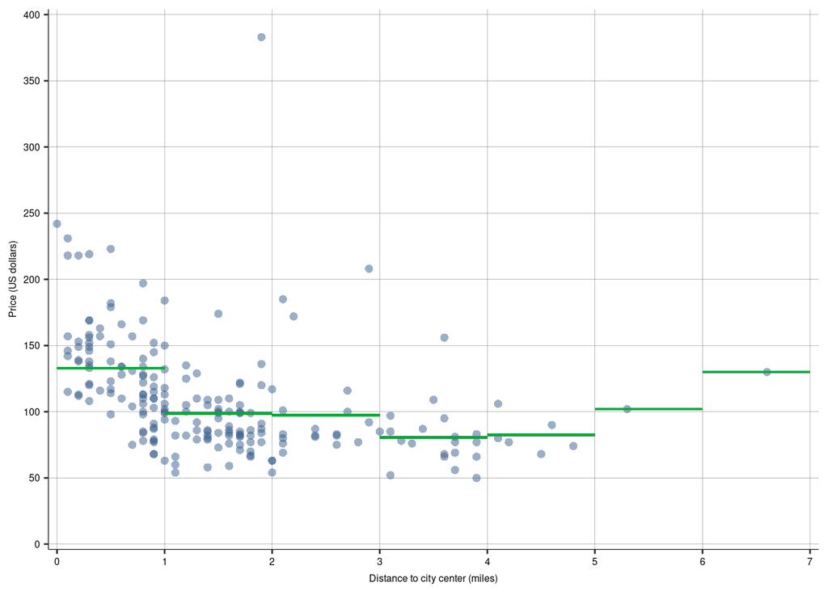

```r
# non-parametric regression with a step function (7 bins)
hotels <- hotels %>% mutate(dist7_s = 1 * as.numeric(hotels$distance >= 1) + 1 * as.numeric(hotels$distance >= 2) + 1 * as.numeric(hotels$distance >= 3) + 1 * as.numeric(hotels$distance >= 4) + 1 * as.numeric(hotels$distance >= 5) + 1 * as.numeric(hotels$distance >= 6))
hotels$xend <- c(hotels$dist7_s + 1)
hotels$yend <- c(hotels$Eprice_cat7_new)

# plotting non-parametric regression including scatterplot (7 bins)
p6 <- p4 +
  geom_segment(data = hotels, aes(x = dist7_s, y = yend, xend = xend, yend = yend), color = color[2], size = 0.7, na.rm = TRUE)
p6
```

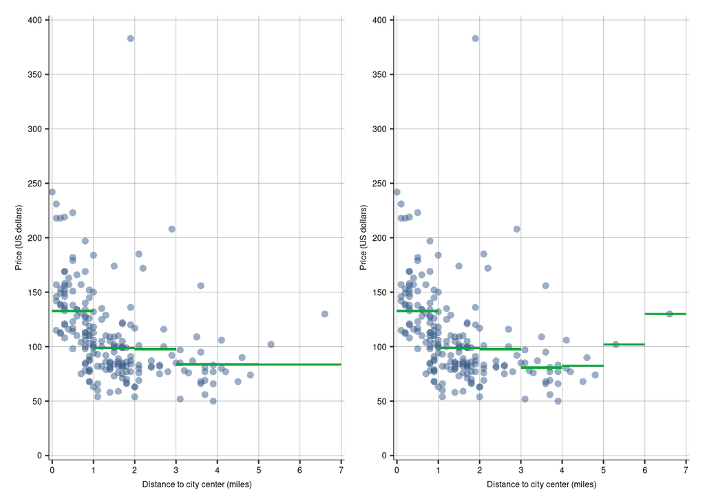

```r
p5 | p6
```

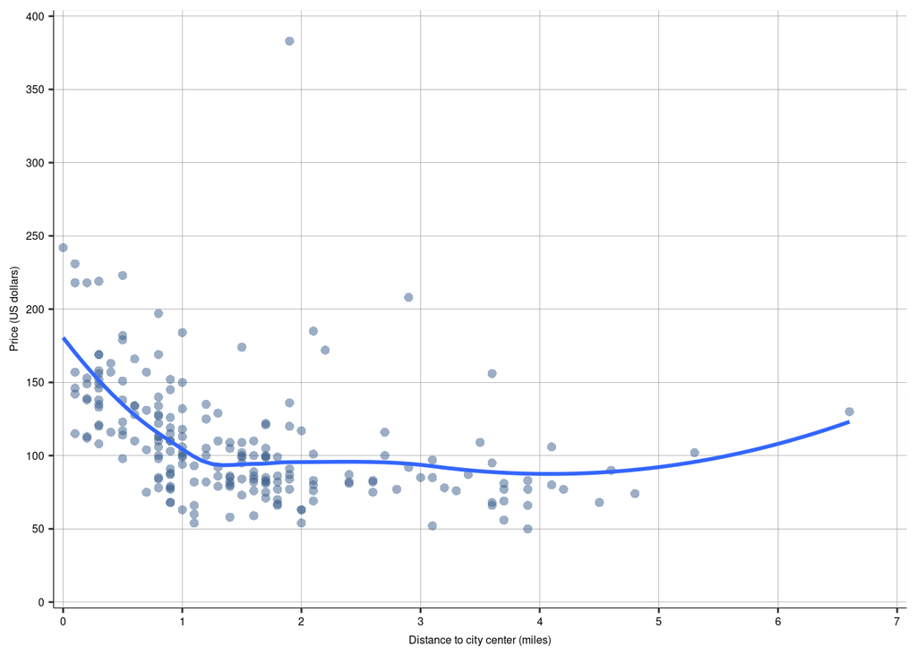

```r
# LOWESS NONPARAMETRIC REGRESSION
p7 <- p4 +
  geom_smooth(aes(x = distance, y = price), method = "loess", se = FALSE)
p7
```

## 8.2 Linear Regression

Simple linear regression imposes linearity of the function *f* in $y^E = f(x)$. Linear functions have two parameters called coefficients: the **intercept coefficient** and the **slope coefficient**.
$$y^E = a + \beta x$$
To be more precise, linear regression imposes linearity in terms of its coefficients. We can have any function, including any nonlinear function, of the original variables themselves, and it will be still a linear regression as long as it consists of an intercept plus a slope coefficient, whether that slope multiplies *x* or any function of *x*.

Linear regression is a line through the *x-y* scatterplot. This line is the best-fitting line one can draw through the scatterplot. It is the best fit in the sense that it is the line that is closest to all points of the scatterplot.

One way to look at the linearity in linear regression is as an assumption: by doing linear regression analysis we assume that the regression function is linear in its coefficients. Another way to look at linearity is to treat it as an approximation. Whatever the form of the $y^E = f(x)$ relationship, the $y^E = a + \beta x$ regression fits a line through it. By fitting a line, linear regression approximates the average slope of the $y^E = f(x)$ curve: it is the difference in average *y* that corresponds to different values of *x*, averaged across the entire range of *x* in the data.

## 8.3 Linear Regression: Coefficient Interpretation

What makes linear regression very powerful is that its coefficients have a clear interpretation based on the idea of comparing conditional means. The **intercept** ($a$) is the average value of *y* when *x* is zero. The **slope** ($\beta$) shows the expected difference in *y* corresponding to a one unit difference in *x*. *y* is higher, on average, by $\beta$ for observations with a one-unit higher value of *x*.

## 8.4 Linear Regression with a Binary Explanatory Variable

An important special case of linear regression is when *x* is a binary variable, zero or one. In this case, the simple linear regression has the following interpretations:

- $a$ (intercept): the average value of *y* is $a$ when *x* is zero.
- $\beta$ (slope): average *y* is $\beta$ higher among observations with $x = 1$ than among observations with $x = 0$.
- When $x = 1$, the average value of *y* is $a + \beta$.

## 8.5 Coefficient Formula

One of the advantages of linear regression is that there are ready formulae for its coefficients. At a practical level, we simply have to plug in appropriate values in the data in these formulae to get the coefficients.

$a$ and $\beta$ denote the coefficients of linear regression in the abstract. The calculated values $\hat{a}$ and $\hat\beta$ are called **estimates** of the coefficients $a$ and $\beta$. The formulae are called **estimators** as they give the estimates once data is plugged into them.

The slope coefficient is calculated by first calculating the covariance of the dependent variable and the explanatory variable in the data and then dividing that by the variance of the explanatory variable in the data:
$$\hat{\beta} = \frac{Cov[x, y]}{Var[x]}$$
One way to understand the slope coefficient formula is to view it as a normalized version of the covariance between *x* and *y*. The slope measures the covariance relative to the variation in *x*. That is why the slope can be interpreted as differences in average *y* corresponding to differences in *x*.

The intercept is calculated after the slope is calculated. It is average *y* minus average *x* multiplied by the estimated slope $\hat{\beta}$:
$$\hat{a} = \bar{y} - \hat{\beta}\bar{x}$$
The formula of the intercept reveals that the regression line always goes through the point of average *x* and average *y*. To see that, just rearrange the formula to get
$$\bar{y} = \hat{a} + \hat{\beta}\bar{x}$$
In linear regressions, the expected value of *y* for average *x* is indeed average *y*. The derivation of the formulae is called **ordinary least squares (OLS)**. Data analysts sometimes use the name OLS for the linear regression with coefficients estimated by ordinary least squares. The linear regression is the best-fitting line through the scatterplot when its coefficients are estimated with OLS. Mathematically, the OLS method finds the values of the coefficients of the linear regression that minimize the sum of squares of the difference between actual *y* values and their values implied by the regression, $\hat{a} + \hat{\beta}\bar{x}$.

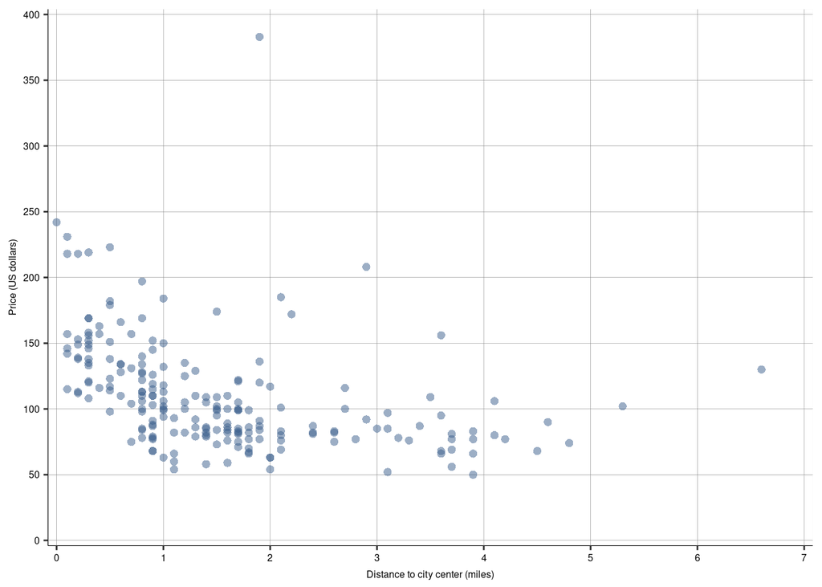

```r
# CASE STUDY: Finding a Good Deal among Hotels with Simple Regression
# load data
hotels <- read_csv("input/hotels-vienna.csv")

# Apply filters:  3-4 stars, Vienna actual, without extreme value
hotels <- hotels |>
  filter(accommodation_type == "Hotel") |>
  filter(city_actual == "Vienna") |>
  filter(stars >= 3 & stars <= 4) |>
  filter(!is.na(stars)) |>
  filter(price <= 600)

# plotting scatterplot
p1 <- ggplot(data = hotels) +
  geom_point(aes(x = distance, y = price), color = color[1], size = 2, shape = 16, alpha = 0.5, show.legend = F, na.rm = TRUE) +
  expand_limits(x = 0.01, y = 0.01) +
  scale_x_continuous(expand = c(0.01, 0.01), limits = c(0, 7), breaks = seq(0, 7, by = 1)) +
  scale_y_continuous(expand = c(0.01, 0.01), limits = c(0, 400), breaks = seq(0, 400, by = 50)) +
  labs(x = "Distance to city center (miles)", y = "Price (US dollars)") +
  theme_bg()
p1
```

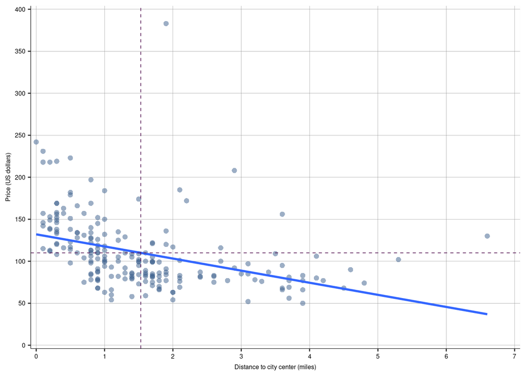

```r
# plotting linear regression + lines for averages
p2 <- p1 +
  geom_smooth(aes(x = distance, y = price), method = "lm", se = FALSE) +
  geom_vline(xintercept = mean(hotels$distance), color = color[3], lty = "dashed", size = 0.3) +
  geom_hline(yintercept = mean(hotels$price), color = color[3], lty = "dashed", size = 0.3)
p2
```

## Predicted Dependent Variable and Regression Residual

The **predicted value** of the dependent variable is our best guess for its average value if we know the value of the explanatory variable. The primary use of the predicted value is in predictive analysis. The predicted value is straightforward to compute in a linear regression:
$$\hat{y}_i = \hat{a} + \hat{\beta}x_i$$
The **residual** is another important measure that we can compute from a regression. It is the difference between the actual value of the dependent variable for an observation and its predicted value:
$$e_i = y_i - \hat{y}_i$$
The concept of the residual is general for all regressions, not only linear regression. The residual is always the difference between the actual dependent variable and the value implied by the regression: $y_i - \hat{y}_i$.

With estimated $\hat{a}$ and $\hat \beta$, the predicted value of *y* can be computed for any value of *x*. This is possible for any *x* value: not only those that correspond to an observation in our data but other values of *x*, too. Computing the predicted value of the dependent variable for non-existing values of the explanatory variable in-between existing values in the data is **interpolation**. Computing it for values of the explanatory variable that are outside its range is called **extrapolation**. In contrast with predicted *y* values, residuals can be computed for existing observations only.

```r
# CASE STUDY: Finding a Good Deal among Hotels with Simple Regression
# load data
hotels <- read_csv("input/hotels-vienna.csv")

# Apply filters:  3-4 stars, Vienna actual, without extreme value
hotels <- hotels |>
  filter(accommodation_type == "Hotel") |>
  filter(city_actual == "Vienna") |>
  filter(stars >= 3 & stars <= 4) |>
  filter(!is.na(stars)) |>
  filter(price <= 600)

# calculating predicted values and the residuals
regression <- lm(price ~ distance, data = hotels)
hotels$predprice <- predict(regression)
hotels$e <- resid(regression)

# values for annotation
xa<- 2.9
ya<- 208
ym<- 90.24

# plotting the regression line and the residual
p1 <- ggplot(data = hotels, aes(x = distance, y = price)) +
  geom_point_da() +
  geom_smooth_da(method = "lm") +
  annotation_custom(grid.text("Residual", x = 0.48, y = 0.5, gp = gpar(color = "black", fontsize = 4, fontface = "bold"))) +
  annotate("pointrange", x = xa, y = ya, ymin = ya, ymax = ya, color = color[3], size = 0.1) +
  geom_errorbar(data = subset(hotels, hotels$distance == xa), aes(x = distance, ymin = ym, ymax = ya), width = 0.2, size = 0.2, color = color[1]) +
  expand_limits(x = 0.01, y = 0.01) +
  scale_x_continuous(expand = c(0.01, 0.01), limits = c(0, 7), breaks = seq(0, 7, by = 1)) +
  scale_y_continuous(expand = c(0.01, 0.01), limits = c(0, 400), breaks = seq(0, 400, by = 50)) +
  labs(x = "Distance to city center (miles)", y = "Price (US dollars)") +
  theme_bg()
```

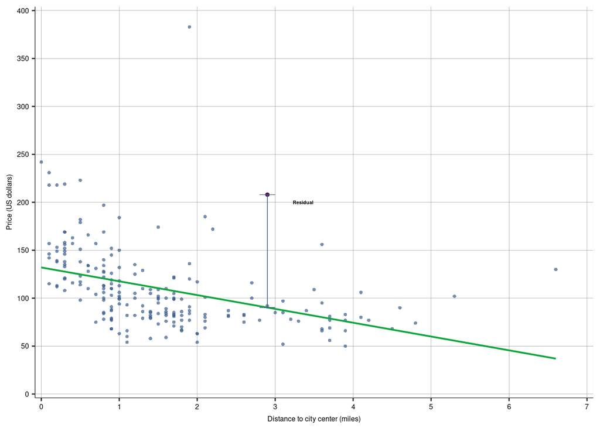

```r
p1
```

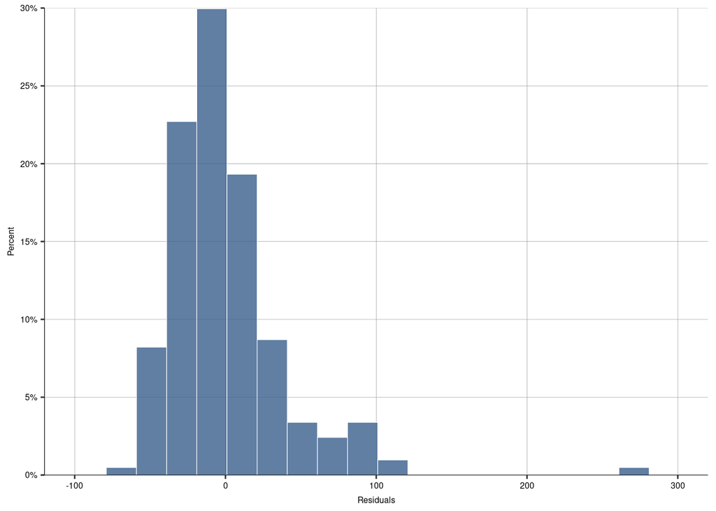

```r
# plotting histogram of the residuals
p2 <- ggplot(data = hotels, aes(x = e)) +
  geom_histogram(aes(y = (..count..) / sum(..count..)),
    binwidth = 20, color = color.outline, fill = theme_colors[1],
    size = 0.2, alpha = 0.8, show.legend = F, na.rm = TRUE, boundary = 1
  ) +
  labs(x = "Residuals", y = "Percent") +
  scale_x_continuous(limits = c(-100, 300), breaks = seq(-100, 300, by = 100)) +
  scale_y_continuous(
    expand = c(0.0, 0.0), limits = c(0, 0.3), breaks = seq(0, 0.3, by = 0.05),
    labels = scales::percent_format(accuracy = 1)
  ) +
  theme_bg()
p2
```

```r
# calculating predicted values and the residuals
reg1 <- lm(price ~ distance, data = hotels)
summary(reg1)
```

```
##
## Call:
## lm(formula = price ~ distance, data = hotels)
##
## Residuals:
##    Min     1Q Median     3Q    Max
## -62.17 -23.39  -8.41  13.49 278.36
##
## Coefficients:
##             Estimate Std. Error t value             Pr(>|t|)
## (Intercept)   132.02       4.47   29.51 < 0.0000000000000002 ***
## distance      -14.41       2.33   -6.18         0.0000000034 ***
## ---
## Signif. codes:  0 '***' 0.001 '**' 0.01 '*' 0.05 '.' 0.1 ' ' 1
##
## Residual standard error: 39 on 205 degrees of freedom
## Multiple R-squared:  0.157,  Adjusted R-squared:  0.153
## F-statistic: 38.2 on 1 and 205 DF,  p-value: 0.00000000339
```

```r
# creating new variables
hotels$reg1_resid <- reg1$residuals
hotels$reg1_res <- ifelse(reg1$residuals >= 0, "overpriced", "underpriced")
hotels$reg1_res <- ifelse(hotels$reg1_resid %in% tail(sort(reg1$residuals, decreasing = TRUE), 5), "bottom5",
  ifelse(hotels$reg1_resid %in% head(sort(reg1$residuals, decreasing = TRUE), 5), "top5", hotels$reg1_res)
)

# creating new data set
bestdeals <- hotels |>
  arrange(e)
bestdeals
```

```
## # A tibble: 207 × 28
##    country city_actual rating_count center1label center2label neighbourhood
##    <chr>   <chr>              <dbl> <chr>        <chr>        <chr>
##  1 Austria Vienna                63 City centre  Donauturm    Josefstadt
##  2 Austria Vienna               203 City centre  Donauturm    Alsergrund
##  3 Austria Vienna               242 City centre  Donauturm    Leopoldstadt
##  4 Austria Vienna               169 City centre  Donauturm    Wieden
##  5 Austria Vienna                43 City centre  Donauturm    Josefstadt
##  6 Austria Vienna                84 City centre  Donauturm    Leopoldstadt
##  7 Austria Vienna               275 City centre  Donauturm    Leopoldstadt
##  8 Austria Vienna               128 City centre  Donauturm    Josefstadt
##  9 Austria Vienna               194 City centre  Donauturm    Favoriten
## 10 Austria Vienna               461 City centre  Donauturm    Leopoldstadt
## # … with 197 more rows, and 22 more variables: price <dbl>, city <chr>,
## #   stars <dbl>, ratingta <dbl>, ratingta_count <dbl>, scarce_room <dbl>,
## #   hotel_id <dbl>, offer <dbl>, offer_cat <chr>, year <dbl>, month <dbl>,
## #   weekend <dbl>, holiday <dbl>, distance <dbl>, distance_alter <dbl>,
## #   accommodation_type <chr>, nnights <dbl>, rating <dbl>, predprice <dbl>,
## #   e <dbl>, reg1_resid <dbl>, reg1_res <chr>
```

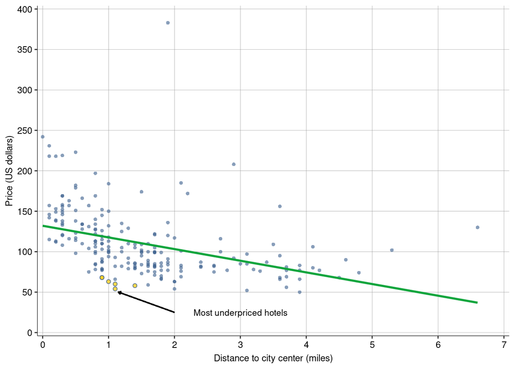

```r
# plotting underpriced hotels
p3 <- ggplot(data = hotels, aes(x = distance, y = price)) +
  geom_point(
    data = filter(hotels, reg1_res == "overpriced"), aes(color = factor(reg1_res)),
    size = 1.3, shape = 16, alpha = 0.6, show.legend = F
  ) +
  geom_point(
    data = filter(hotels, reg1_res == "underpriced"), aes(color = factor(reg1_res)),
    size = 1.3, shape = 16, alpha = 0.6, show.legend = F
  ) +
  geom_point(
    data = filter(hotels, reg1_res == "bottom5"), aes(color = factor(reg1_res), fill = factor(reg1_res)),
    size = 1.5, shape = 21, alpha = 0.8, show.legend = F
  ) +
  geom_point(
    data = filter(hotels, reg1_res == "top5"), aes(color = factor(reg1_res)),
    size = 1.3, shape = 16, alpha = 0.6, show.legend = F
  ) +
  geom_smooth_da(method = "lm", size = 1) +
  coord_cartesian(xlim = c(0, 7), ylim = c(0, 400)) +
  expand_limits(x = 0.01, y = 0.01) +
  scale_x_continuous(expand = c(0.01, 0.01), limits = c(0, 7), breaks = seq(0, 7, by = 1)) +
  scale_y_continuous(expand = c(0.01, 0.01), limits = c(0, 400), breaks = seq(0, 400, by = 50)) +
  labs(x = "Distance to city center (miles)", y = "Price (US dollars)") +
  scale_color_manual(
    name = "",
    values = c(color[1], color[1], color[1], color[1])
  ) +
  scale_fill_manual(name = "", values = c(color[4])) +
  geom_segment(aes(x = 2, y = 25, xend = 1.15, yend = 50), arrow = arrow(length = unit(0.1, "cm"))) +
  annotate("text", x = 3, y = 25, label = "Most underpriced hotels", size = 3) +
  theme_bg() +
  theme(axis.text.x = element_text(size = 9)) +
  theme(axis.text.y = element_text(size = 9)) +
  theme(axis.title.x = element_text(size = 9)) +
  theme(axis.title.y = element_text(size = 9))
p3
```

## Goodness of Fit, R-Squared

An important property of regression is how well it fits the data, called **goodness of fit**. The **fit of a regression** captures how these predicted values compare to the actual values. The most commonly used measure of the fit of a regression is the **R-squared ($R^2$)**. R-squared captures how close the predicted *y* values are to the actual values. It does so by measuring how much of the variation in *y* is captured by the regression, and how much is left for residual variation:
$$R² = \frac{Var[\hat{y}]}{Var[y]} = 1 - \frac{Var[e]}{Var[y]}$$
This is based on the decomposition of the overall variation in the dependent variable into variation in predicted values (variation “explained by the regression”) and the remaining, residual variation (variation “not explained by the regression”):
$$Var[y] = Var[\hat{y}] + Var[e]$$

R-squared (or $R²$) can be defined for both parametric and non-parametric regressions. The value of R-squared is always between zero and one. R-squared is one if the regression fits the data perfectly. In this case each and every data point is equal to its predicted value from regression, and all residuals are zero. The other polar case is an R-squared of zero. In this case all of the $\hat{y}$ values are equal to the overall average value $\bar{y}$ in the data regardless of the value of the explanatory variable *x*. This corresponds to a slope of zero: the regression line is completely flat.

The fit of a regression depends on two factors:

1. how well the particular version of the regression captures the actual function *f* in $y^E = f(x)$;
2. how far actual values of *y* are spread around what would be predicted using the actual function *f*.

A non-parametric regression almost always gives a better fit than a linear regression. When our goal is prediction, R-squared may help in choosing between different versions of regression for the same data. Besides giving information on the fit of a particular regression R-squared is used to compare alternative regressions that use different *x* variables to predict the same *y* variable. Comparing two regressions, the one with a higher R-squared does a better job at predicting *y* in the data.

## 8.6 Correlation and Linear Regression

Linear regression is closely related to correlation. The correlation coefficient measures the degree of association between two variables. It is a normalized version of the covariance, dividing it by the standard deviations of the two variables. The OLS formula for the slope estimate of the linear regression is also a normalized version of the covariance, only here it is divided by the variance of the *x* variable.

Despite their differences, the **covariance**, the **correlation coefficient**, and the **slope of a linear regression** capture similar information: the degree of association between the two variables. The relationship between the slope coefficient of the simple linear regression and the correlation coefficient helps to explain the name for the method itself: regression. It is so called due to the Sir Francis Galton’s study on the association between the height of parents *(x)* and the height of their children *(y)*: events further away from the mean tend to be followed by events closer to the mean.

## 8.7 Regression and Causation

The slope of a simple regression describes the same association as correlation, but it does not show the effect of the explanatory variable on the dependent variable. Regression is a method of comparison: it compares observations that are different in *x* and shows corresponding average differences in *y*. It is a way to find patterns of association by comparisons. Regression analysis cannot in general uncover the effect of *x* on *y* in observational data because there variation in *x* is not controlled. In contrast, the same regression analysis can uncover the effect of *x* on *y* in experimental data where variation in *x* is controlled.

In any case, when the slope of the regression is not zero in our data, one of three things may be true:

1. *x* causes *y*. If this is the single one thing behind the slope, it means that we can expect *y* to increase by $\beta$ units if we were to increase *x* by one unit.
2. *y* causes *x*. If this is the single one thing behind the slope, it means that me can expect *x* to increase if we were to increase *y*.
3. A third variable causes both *x* and *y* (or many such variables do). If this is the single one thing behind the slope it means that we cannot expect *y* to increase if we were to increase *x*.

# 9 CHAPTER 08: Complicated Patterns and Messy Data

Whether the shape of a regression is linear or nonlinear matters if:

- our goal is prediction;
- our goal is uncovering the patterns of association and we want to uncover more than the average association;
- all we want to uncover is the average association, but that average is badly estimated due to nonlinearities (most often due to strong skewness or extreme values).

## 9.1 Taking Relative Differences or Logs

Some frequent nonlinear patterns are better approximated by linear regressions if *y* or *x*, or both, are transformed by taking **relative differences**, or **percentage differences**. In a time series, this transformation is possible because there is a previous observation that could serve as the natural base for comparison. But doing so is impossible in cross-sectional data where there is no previous observation that could serve as a natural base for comparison. Taking the **natural logarithm** of a variable is often a good solution in such cases. When transformed by taking the natural logarithm, differences in variable values approximate relative differences.

The natural logarithm of a variable *x* is denoted as $ln(x)$ or ln *x*. When we want to differentiate variables that are not in logs, we often say that they are in **level**, or levels. Examining log differences works because differences in natural logs approximate percentage differences. Log differences are approximations of percentage differences that work well for small differences of 30% or less. For larger positive differences, the log difference is smaller (for example, a log difference of +1.0 corresponds to a +170% difference). For larger negative differences, the log difference is larger in absolute value (for example, a log difference of -1.0 corresponds to a -63% difference).

Measuring differences in relative terms is often a good choice with many variables analyzed in business, economics, and policy:

- Relative comparisons are free from measures of the variables that are often different across time and space and are arbitrary to begin with.
- Differences in relative terms are likely to be more stable across time and space than absolute differences.
- Many economic decisions are based on differences in relative terms.

The distribution of variables in relative terms, including after taking the log, is often less skewed than distributions of levels. The distribution of many important economic variables is skewed with a long right tail and are reasonably well approximated by a **log normal distribution**. The natural log of such variables are close to normally distributed with all of the associated nice statistical properties such as symmetry and low frequency of extreme values. Having variables with such nice properties is a good thing in linear regression analysis: the slope in a linear regression is an approximation of the average slope of an underlying conditional expectation that may be nonlinear. Thus, the closer the distribution of variables is to normal, the better the approximation.

Taking relative differences or logs keeps some aspects of the variables the same but changes other aspects.

1. Relative differences and log differences between two observations are not affected by the original units of measurement. This is true for units of measurements that are multiples of each other, such as currencies or distance. The same is not true for additive transformations. For this reason, it makes most sense to take relative differences or logs of ratio variables only.
2. When we take the log of a variable, we do a monotonic transformation: the ordering of observations in terms of a transformed variable is the same as their ordering in terms of the original variable.
3. Taking relative, or log differences is tricky with averages. In general, the average of many relative, or log differences, is not equal to the relative, or log difference, of average variables. Technically this is because the log is a nonlinear function.

One of the main reason to take relative differences, or logs, of variables is to consider differences in relative terms that are free from arbitrary units of measurement and represent how decision makers think about them. The statistical reason is to transform variables that are skewed with a long right tail to variables that are more symmetric and closer to being normally distributed.

## 9.2 Log Transformations and Non-positive Values

An important constraint on taking relative differences or logs is that they are possible for positive values only. And that can be a problem, because we may encounter variables that we want to analyze in relative terms yet they have non-positive values:

1. The reason for zero, or negative, values may matter. In particular, the variable may have only positive values in principle, but the data has zeros because of rounding. When zeros are the results of rounding, it’s good practice to replace those apparently zero values with what may be the average non-rounded value for them, such as 0.25 (if values below 0.5 are rounded to zero and the distribution of the variable is likely close to uniform in that region).
2. The magnitude of the problem matters. If only 1 percent of the observations have zero value, we may simply drop them from the data. If, in contrast, 60 percent, or 90 percent, have zero value, whether a value is zero or positive is important information. So much so that we may convert this variable into a binary one.
3. The available options are different for the *y* and *x* variables in the regression whether the non-positive values are all zero, or there are negative values, too:
- The *x* variable is positive for most observations and zero for a non-negligible minority of the observations. In this case it is a good practice to create a binary variable denoting whether $x = 0$. Then we make ln $x = 0$ when $x = 0$, and enter both the binary variable and this modified ln $x$ in the regression. The interpretation of the first coefficient is the usual one with ln $x = 0$ versus $x \gt 0$, and the interpretation of the second coefficient is the usual one with ln $x$, given that $x \gt 0$.
- We can follow the same logic with an *x* variable that is positive for some observations but zero or negative for a non-negligible minority of the observations. Here we can define a binary variable denoting whether $x \leq 0$. Alternatively, we can create two binary variables, one for whether $x = 0$, and one for whether $x \lt 0$. Either way, we replace ln $x = 0$ for all $x \le 0$ observations, enter the binary variable, or variables, together with ln $x$, and interpret their coefficients accordingly.

# 10 Linting

The code in this RMarkdown is linted with the [lintr package](https://github.com/jimhester/lintr), which is based on the [tidyverse style guide](http://style.tidyverse.org/).

```r
# lintr::lint("main.Rmd", linters =
#               lintr::with_defaults(
#                 commented_code_linter = NULL,
#                 trailing_whitespace_linter = NULL
#                 )
#             )
# if you have additional scripts and want them to be linted too, add them here
# lintr::lint("scripts/my_script.R")
```